# lab3

Benjamin G. Moran

8 August 2016

### Question 1

We looked at this question last week. Use Monte Carlo simulation to get the same answers as last week to 2 decimal places.

1. A basketball fan watches Michael Jordan and of 100 randomly chosen free throws in 20 games, Jordan makes 89 of them. Given a uniform prior, find the posterior density for the true proportion of successful free throws and a 95% credible interval. Plot this density.
2. The same fan watches Shaquille O’Neal make only 40 out of 100 randomly chosen free throws from 20 games. Find the posterior density for his success proportion using a uniform prior and a 95% credible interval. Plot this density.
3. Use what you know about these two players (if anything) to construct a Beta prior distribution for their success proportions at making free-throws and repeat the analysis in (a) and (b).
4. What is the probability that Jordan’s free-throw percentage is above 90% from part (a)? From part (c)?
5. How many iterations did you need to get 2 decimal places of accuracy? What about 3 or more? How many places of accuracy do we need?
6. How can we compare the two success proportions? Is Jordan significantly better than O’Neal? What is the probability that Jordan is better than O’Neal? Use MC simulation to answer.
7. More interestingly, do this analysis for if O’Neal’s performance had been 80 out of 100. Provide the appropriate graph.

**Answer**

```r
a <- 1
b <- 1
n <- 100
factor <- 100
bounds <- c(0.025, 0.9975)

successes <- 89


# a) A binomial(a,n) * a Unif[0,1] -> a Beta(a+1, n-a+1)

post.CrI <- qbeta(bounds, successes + a, n - successes + b)
post.CrI
```

```
## [1] 0.8134799 0.9537120
```

```r
# c) Posterior Densities and quantiles

theta.Jordan <- rbeta(n*factor, successes + 1, n - successes + b)
quantile(theta.Jordan, bounds)
```

```
##      2.5%    99.75%
## 0.8133859 0.9546912
```

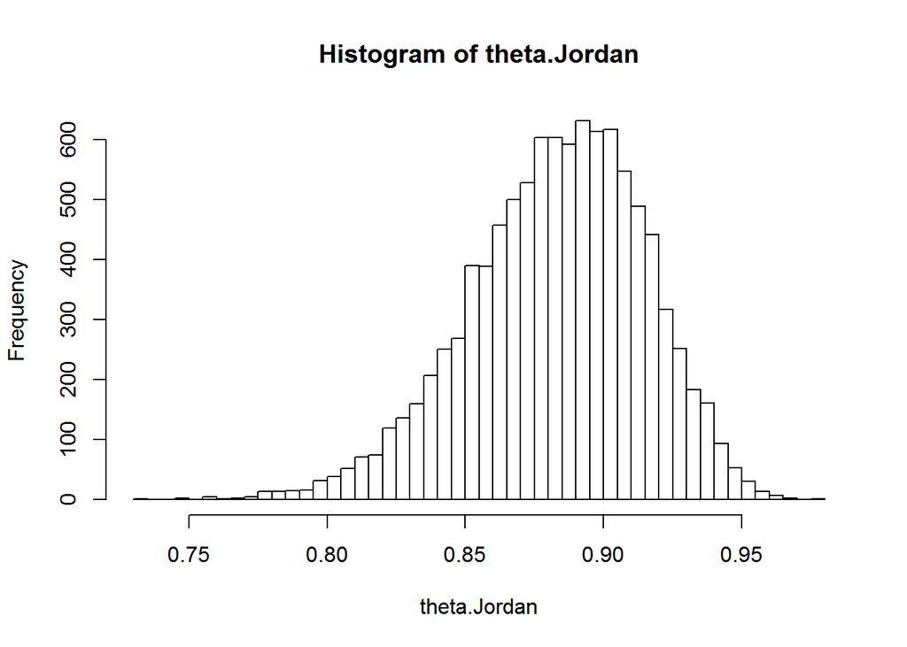

```r
hist(theta.Jordan, 50)
```

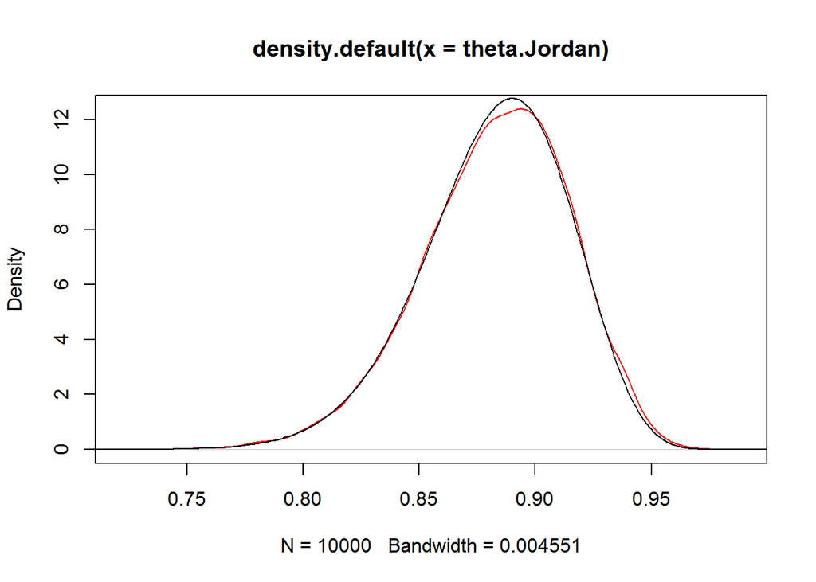

```r
plot(density(theta.Jordan), col = "red")
th1 <- seq(0,1,0.001)
lines(th1,dbeta(th1,successes + a, n - successes + b))
```

```r
dbeta.Jordan <- dbeta(th1,successes + a, n - successes + b)

#Probability of Jordan being 90% accurate with flat priors.
1-pbeta(0.9, successes + a, n - successes + b)
```

```
## [1] 0.3089547
```

```r
sum(theta.Jordan>0.9)/10000
```

```
## [1] 0.3209
```

```r
a <- 1
b <- 1

successes <- 40
bounds <- c(0.025, 0.9975)

# b) A binomial(a,n) * a Unif[0,1] -> a Beta(a+1, n-a+1)

post.CrI <- qbeta(bounds, successes + a, n - successes + b)
post.CrI
```

```
## [1] 0.3093085 0.5403139
```

```r
# c) Posterior Densities and quantiles

theta.ONeal <- rbeta(n*factor, successes + 1, n - successes + b)
quantile(theta.ONeal, bounds)
```

```
##      2.5%    99.75%
## 0.3094644 0.5408522
```

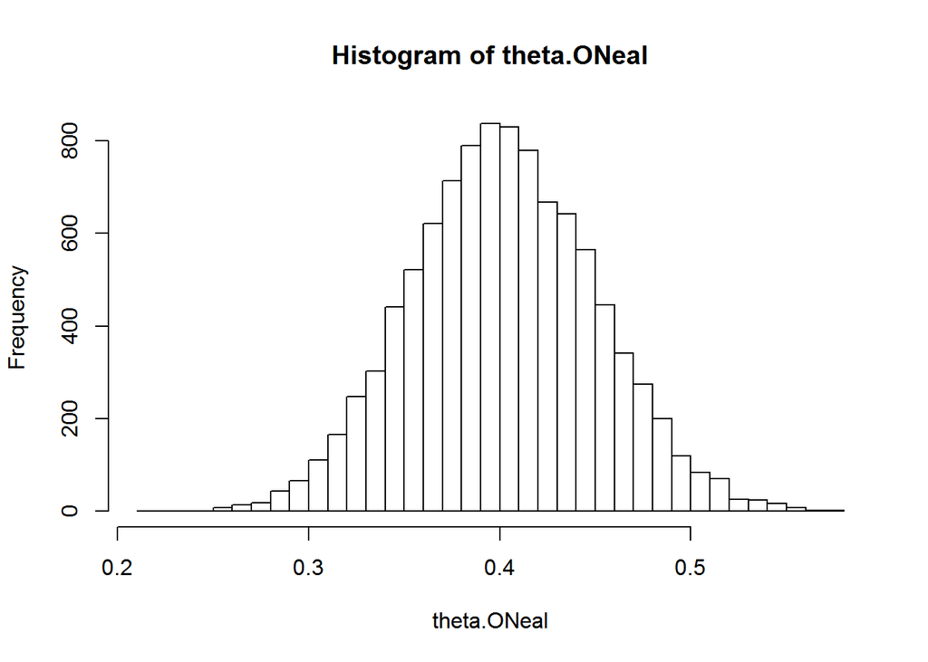

```r
# Plot the histogram and the smoothed density (simulation) overlayed with the function (dbeta)

hist(theta.ONeal, 50)
```

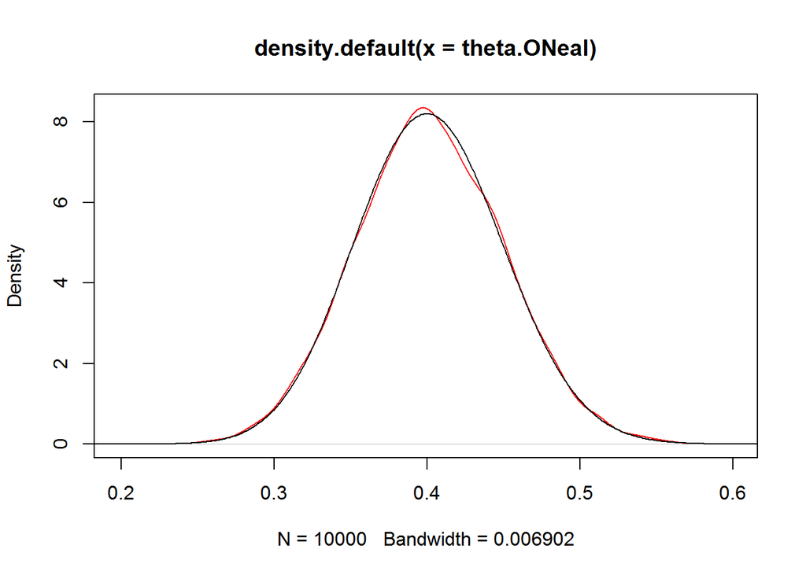

```r
plot(density(theta.ONeal), col = "red")
lines(th1,dbeta(th1,successes + a, n - successes + b))
```

```r
dbeta.ONeal <- dbeta(th1,successes + a, n - successes + b)

#Probability of ONeal being 40% accurate with flat priors.
1-pbeta(0.4, successes + a, n - successes + b)
```

```
## [1] 0.5108068
```

```r
sum(theta.ONeal>0.4)/10000
```

```
## [1] 0.5097
```

Now plot both sample densities on the same graph

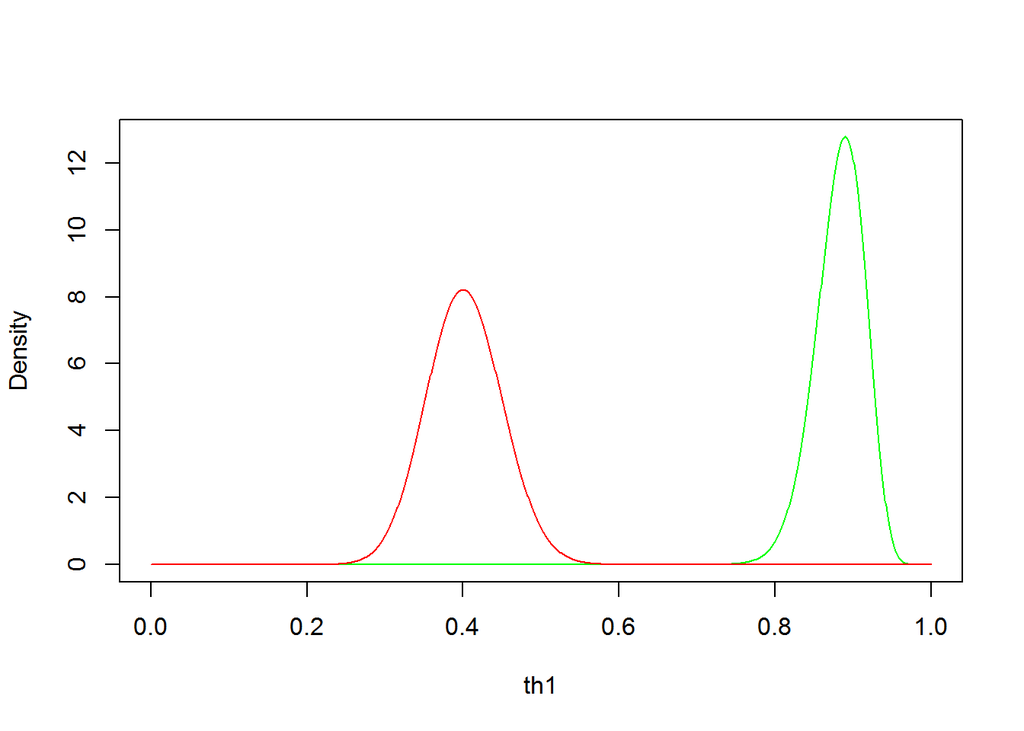

```r
plot(th1, dbeta.Jordan, col = "green", type = 'l', ylab = "Density")
lines(th1, dbeta.ONeal, col = "red", type = 'l')
```

```r
# f) the probability that theta.Jordan is greater than theta.ONeal

mean(theta.Jordan>theta.ONeal)
```

```
## [1] 1
```

```r
a <- 1
b <- 1

successes <- 80
bounds <- c(0.025, 0.9975)

# b) A binomial(a,n) * a Unif[0,1] -> a Beta(a+1, n-a+1)

post.CrI <- qbeta(bounds, successes + a, n - successes + b)
post.CrI
```

```
## [1] 0.7108771 0.8916714
```

```r
# c) Posterior Densities and quantiles

theta.ONeal2 <- rbeta(n*factor, successes + 1, n - successes + b)
quantile(theta.ONeal2, bounds)
```

```
##      2.5%    99.75%
## 0.7122400 0.8901282
```

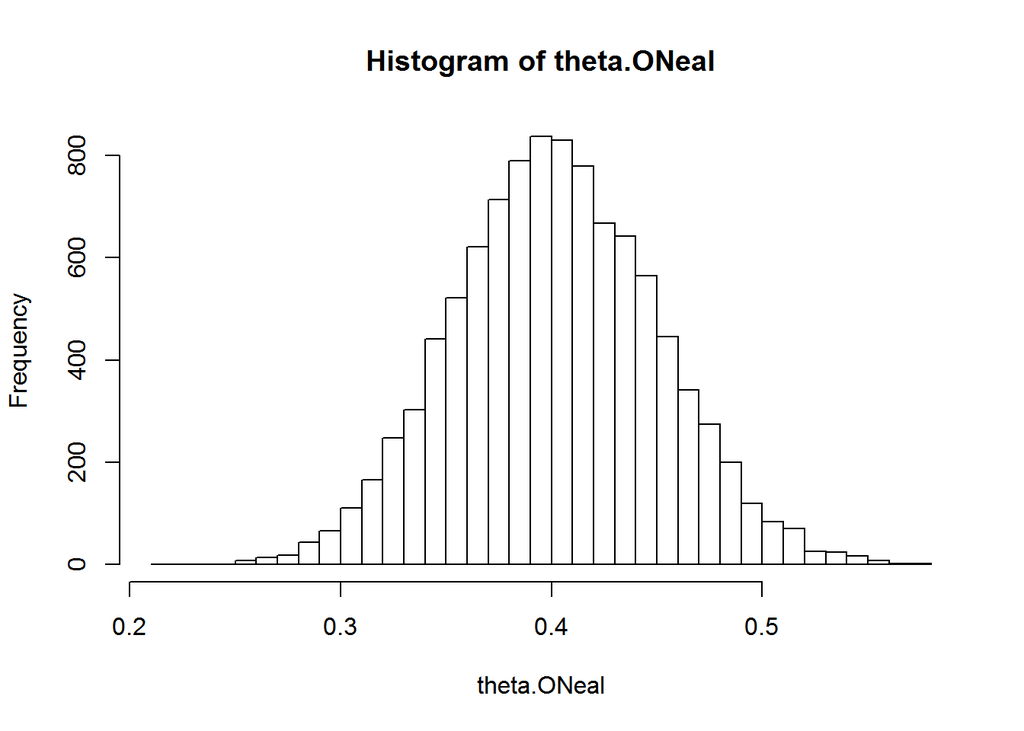

```r
# Plot the histogram and the smoothed density (simulation) overlayed with the function (dbeta)

hist(theta.ONeal, 50)
```

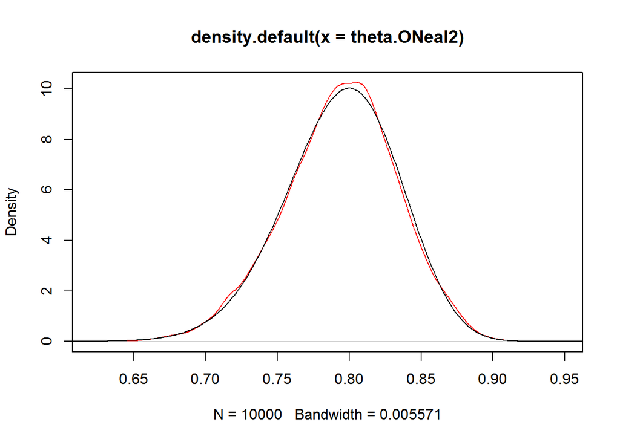

```r
plot(density(theta.ONeal2), col = "red")
lines(th1,dbeta(th1,successes + a, n - successes + b))
```

```r
dbeta.ONeal2 <- dbeta(th1,successes + a, n - successes + b)

#Probability of ONeal being 40% accurate with flat priors.
1-pbeta(0.8, successes + a, n - successes + b)
```

```
## [1] 0.4603985
```

```r
sum(theta.ONeal2>0.8)/10000
```

```
## [1] 0.4578
```

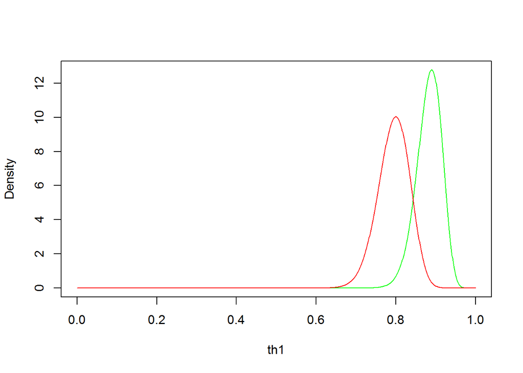

```r
plot(th1, dbeta.Jordan, col = "green", type = 'l', ylab = "Density")
lines(th1, dbeta.ONeal2, col = "red", type = 'l')
```

```r
# f) the probability that theta.Jordan is greater than theta.ONeal

mean(theta.Jordan>theta.ONeal2)
```

```
## [1] 0.96
```

### Question 2

Consider again the placenta previa example, where y = no. of female births and $\theta$ = Pr(female birth); we will take a sample of $n=1000$.

1. After consultation with a specialist in Placenta previa, you place a $Beta(100,100)$ prior on $\theta$. Show that this means that you (and the doctor) are more than $95\%$sure that $0.4 < \theta < 0.6$; but that you are undecided whether $\theta > 0.5$ OR $\theta < 0.5$.
2. Is this a reasonable prior distribution?

```r
n <- 1000
a <- 100
b <- 100
pbeta(0.6, a, b) - pbeta(0.4, a, b)
```

```
## [1] 0.9956798
```

```r
c <- pbeta(c(0.6,0.4),a,b)
qbeta(c, a,b)
```

```
## [1] 0.6 0.4
```

```r
# e)
births <- 1000
males <- 511
mu <- 0.5
sig2 <- 0.01
a <- mu*(mu*(1-mu)/sig2 -1)
b <- (1-mu)*(mu*(1-mu)/sig2 -1)
theta.males <- rbeta(births, males + a, births - males + b)
sum(theta.males>0.5)/births
```

```
## [1] 0.756
```

```r
1 - pbeta(0.5, males + a, births - males + b)
```

```
## [1] 0.7542126
```

### Question 3

1. A single sample of $y=1$ is observed. Update the discrete probability distribution for $\theta$ using Bayes’ rule. i.e. find $p(\theta|y=1)$.

```r
# THis part is confusing. CHeck the answers on Tuesday night.

y <- 1
sig <- 2
x.1 <- dnorm(y,1,sig)
x.1
```

```
## [1] 0.1994711
```

```r
x.2 <- dnorm(y, 1, sig)*0.5
x.2
```

```
## [1] 0.09973557
```

```r
x.3 <- dnorm(y, 2, sig)
x.3
```

```
## [1] 0.1760327
```

```r
x.4 <- dnorm(y, 2, sig)*0.5
x.4
```

```
## [1] 0.08801633
```

```r
# theta1.post
# theta2.post
```

2. A single observation of $y = 1.5$ is observed. Update the prior, ignoring the data point in part (a).
3. Update the prior using Bayes’ rule after observing both sample points in (a)and (b). That is we have a sample of size 2, $y_1 = 1, y_2 = 1.5$.
4. Use probability rules to find the marginal likelihood $p(y)$, i.e. the likelihood unconditional on $\theta$. Plot this likelihood over a sensible grid of points. θ